# HW8

Ethan Dean

March 31 2021

# Study System

I am using the example data from an experiment I am creating on CPB. In this I am exposing beetles to curcumin and seeing how that changes their survival because it should cause changes in their epigenetic mechanisms possibly associated with insecticide resistance.

If this were true I would see less survive when exposed to the determined LC50 when exposed to these chemicals.

# Deciding on Data formats

I decided on the values based on my previous research into the topic and talking with the other people in my lab. Generally this is the ideal outcome I would like with a 25% increase in mortality, however when looking at the minimum needed value (helping me determine variance) they said that in my experiment a change of a few percent would still generally be significant.

I also did this many beetles because I cannot do this in lab because of time being an undergraduate, but ideally I would love 1000 replicates.

# Creating Random Data and Analyze the data

```r
library(ggplot2)

# Control survival when exposed to lc50 with survivors being 1

Survival_C = rnorm(1000, mean = 0.5, sd = 1)

# 0.25mg curcumin exposure survival rate

Survival_L = rnorm(1000, mean = 0.4, sd = 1)

# 1mg curcumin exposure survival rate

Survival_H = rnorm(1000, mean = 0.3, sd = 1)

# Organize data ------------------------------

survival_total = data.frame(ID = 1:3000, c(Survival_C, Survival_L, Survival_H), Treatment = c(rep('control', 1000), rep('low_curcumin', 1000), rep('high_curcumin', 1000)))

colnames(survival_total)[2] <- ('Survival')

# analyze the data ------------------------------

summary_surv = summary(survival_total)
print(summary_surv)
```

```
##        ID            Survival        Treatment
##  Min.   :   1.0   Min.   :-3.2591   Length:3000
##  1st Qu.: 750.8   1st Qu.:-0.3037   Class :character
##  Median :1500.5   Median : 0.3800   Mode  :character
##  Mean   :1500.5   Mean   : 0.3754
##  3rd Qu.:2250.2   3rd Qu.: 1.0649
##  Max.   :3000.0   Max.   : 3.9824
```

```r
stats <- aov(Survival ~ Treatment, data = survival_total)

stats_sum <- summary(stats)

print(stats_sum)
```

```
##               Df Sum Sq Mean Sq F value   Pr(>F)
## Treatment      2   51.5   25.76    25.5 1.04e-11 ***
## Residuals   2997 3027.0    1.01
## ---
## Signif. codes:  0 '***' 0.001 '**' 0.01 '*' 0.05 '.' 0.1 ' ' 1
```

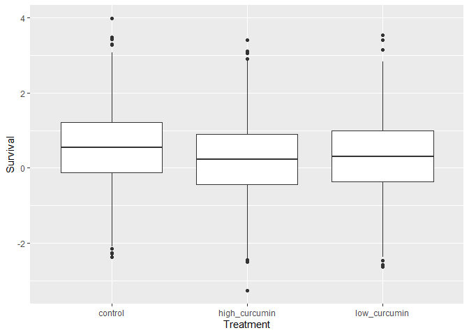

```r
# create a boxplot ------------------------------

ano_plot <- ggplot(stats) + aes(x = Treatment, y = Survival) + geom_boxplot()

print(ano_plot)
```

# Running an additional time

```r
library(ggplot2)

# create data ------------------------------

# Control survival when exposed to lc50 with survivors being 1

Survival_C = rnorm(1000, mean = 0.5, sd = 1)

# 0.25mg curcumin exposure survival rate

Survival_L = rnorm(1000, mean = 0.4, sd = 1)

# 1mg curcumin exposure survival rate

Survival_H = rnorm(1000, mean = 0.3, sd = 1)

# Organize data ------------------------------

survival_total = data.frame(ID = 1:3000, c(Survival_C, Survival_L, Survival_H), Treatment = c(rep('control', 1000), rep('low_curcumin', 1000), rep('high_curcumin', 1000)))

colnames(survival_total)[2] <- ('Survival')

# analyze the data ------------------------------

summary_surv = summary(survival_total)
print(summary_surv)
```

```
##        ID            Survival        Treatment
##  Min.   :   1.0   Min.   :-2.9890   Length:3000
##  1st Qu.: 750.8   1st Qu.:-0.2426   Class :character
##  Median :1500.5   Median : 0.4278   Mode  :character
##  Mean   :1500.5   Mean   : 0.4288
##  3rd Qu.:2250.2   3rd Qu.: 1.0916
##  Max.   :3000.0   Max.   : 3.8499
```

```r
stats <- aov(Survival ~ Treatment, data = survival_total)

stats_sum <- summary(stats)

print(stats_sum)
```

```
##               Df Sum Sq Mean Sq F value   Pr(>F)
## Treatment      2   23.5  11.737   12.12 5.72e-06 ***
## Residuals   2997 2902.1   0.968
## ---
## Signif. codes:  0 '***' 0.001 '**' 0.01 '*' 0.05 '.' 0.1 ' ' 1
```

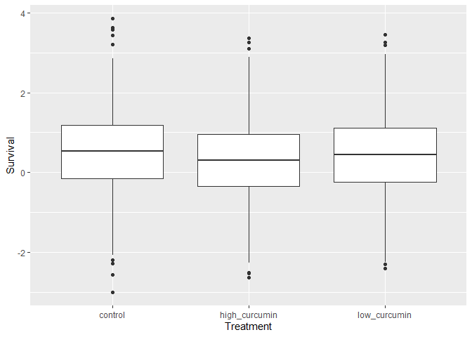

```r
# create a boxplot ------------------------------

ano_plot <- ggplot(stats) + aes(x = Treatment, y = Survival) + geom_boxplot()

print(ano_plot)
```

# Adjusted Means

```r
library(ggplot2)

# create data ------------------------------

# Control survival when exposed to lc50 with survivors being 1

Survival_C = rnorm(1000, mean = 0.5, sd = 1)

# 0.25mg curcumin exposure survival rate

Survival_L = rnorm(1000, mean = 0.46, sd = 1)

# 1mg curcumin exposure survival rate

Survival_H = rnorm(1000, mean = 0.43, sd = 1)

# Organize data ------------------------------

survival_total = data.frame(ID = 1:3000, c(Survival_C, Survival_L, Survival_H), Treatment = c(rep('control', 1000), rep('low_curcumin', 1000), rep('high_curcumin', 1000)))

colnames(survival_total)[2] <- ('Survival')

# analyze the data ------------------------------

summary_surv = summary(survival_total)
print(summary_surv)
```

```
##        ID            Survival        Treatment
##  Min.   :   1.0   Min.   :-2.6489   Length:3000
##  1st Qu.: 750.8   1st Qu.:-0.2029   Class :character
##  Median :1500.5   Median : 0.4747   Mode  :character
##  Mean   :1500.5   Mean   : 0.4656
##  3rd Qu.:2250.2   3rd Qu.: 1.1315
##  Max.   :3000.0   Max.   : 3.9221
```

```r
stats <- aov(Survival ~ Treatment, data = survival_total)

stats_sum <- summary(stats)

print(stats_sum)
```

```
##               Df Sum Sq Mean Sq F value Pr(>F)
## Treatment      2    3.6   1.792   1.865  0.155
## Residuals   2997 2880.2   0.961
```

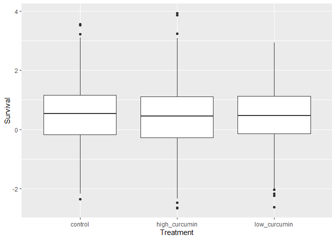

```r
# create a boxplot ------------------------------

ano_plot <- ggplot(stats) + aes(x = Treatment, y = Survival) + geom_boxplot()

print(ano_plot)
```

# Minimum Sample

The lowest I could get here was 360. Even changing a little bit to 350 it seemed made all of the data insignificant. This was good as the sample was cut down close to a third and still showed significance.

```r
# create data ------------------------------

# Control survival when exposed to lc50 with survivors being 1

Survival_C = rnorm(360, mean = 0.5, sd = 1)

# 0.25mg curcumin exposure survival rate

Survival_L = rnorm(360, mean = 0.4, sd = 1)

# 1mg curcumin exposure survival rate

Survival_H = rnorm(360, mean = 0.3, sd = 1)

# Organize data ------------------------------

survival_total = data.frame(ID = 1:360, c(Survival_C, Survival_L, Survival_H), Treatment = c(rep('control', 360), rep('low_curcumin', 360), rep('high_curcumin', 360)))

colnames(survival_total)[2] <- ('Survival')

# analyze the data ------------------------------

summary_surv = summary(survival_total)
print(summary_surv)
```

```
##        ID            Survival        Treatment
##  Min.   :  1.00   Min.   :-2.4933   Length:1080
##  1st Qu.: 90.75   1st Qu.:-0.2411   Class :character
##  Median :180.50   Median : 0.3819   Mode  :character
##  Mean   :180.50   Mean   : 0.4290
##  3rd Qu.:270.25   3rd Qu.: 1.1076
##  Max.   :360.00   Max.   : 3.6271
```

```r
stats <- aov(Survival ~ Treatment, data = survival_total)

stats_sum <- summary(stats)

print(stats_sum)
```

```
##               Df Sum Sq Mean Sq F value   Pr(>F)
## Treatment      2   17.9   8.966   9.094 0.000121 ***
## Residuals   1077 1061.9   0.986
## ---
## Signif. codes:  0 '***' 0.001 '**' 0.01 '*' 0.05 '.' 0.1 ' ' 1
```

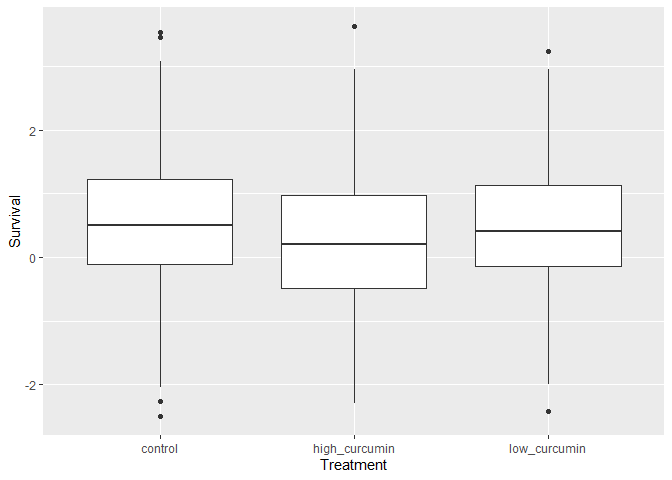

```r
# create a boxplot ------------------------------

ano_plot <- ggplot(stats) + aes(x = Treatment, y = Survival) + geom_boxplot()

print(ano_plot)
```